# Research on car sales ads

### Author: Xia Cui

### Introduction

The report presents the exploratory analysis of a dataset of 51525 free advertisements for vehicles on Crankshaft list, posted from 2018-05-01 to 2019-04-19.

At the data preprocessing stage, we will address the issues of missing values and wrong data types, and also add columns where it fits in order to maximize the information it can present.

The analysis that follows first of all examines the pattern of the advertisements in a range of factors such as price, model year, cylinders, and mileage. Then we will look at what are the characteristics of cars that tend to be gone quickly, as well as of those that stay on the list longer than most. Finally, we will take a closer look at car prices, and investigate which factors influence the price of a vehicle, using the two most popular vehicle types as examples.

### Table of Content

#### Part 1: data importing

#### Part 2: data preprocessing

#### Part 3: adding new columns

#### Part 4: exploratory data analysis

#### Part 5: conclusion

```python
import pandas as pd
import numpy as np
import matplotlib.pyplot as plt
from IPython.display import display
import seaborn as sns
%matplotlib inline
```

### Part 1: Data importing

```python
vehicles = pd.read_csv('https://code.s3.yandex.net/datasets/vehicles_us.csv')
vehicles.head()
```

|  | price | model_year | model | condition | cylinders | fuel | odometer | transmission | type | paint_color | is_4wd | date_posted | days_listed |
| --- | --- | --- | --- | --- | --- | --- | --- | --- | --- | --- | --- | --- | --- |
| 0 | 9400 | 2011.0 | bmw x5 | good | 6.0 | gas | 145000.0 | automatic | SUV | NaN | 1.0 | 2018-06-23 | 19 |
| 1 | 25500 | NaN | ford f-150 | good | 6.0 | gas | 88705.0 | automatic | pickup | white | 1.0 | 2018-10-19 | 50 |
| 2 | 5500 | 2013.0 | hyundai sonata | like new | 4.0 | gas | 110000.0 | automatic | sedan | red | NaN | 2019-02-07 | 79 |
| 3 | 1500 | 2003.0 | ford f-150 | fair | 8.0 | gas | NaN | automatic | pickup | NaN | NaN | 2019-03-22 | 9 |
| 4 | 14900 | 2017.0 | chrysler 200 | excellent | 4.0 | gas | 80903.0 | automatic | sedan | black | NaN | 2019-04-02 | 28 |

```python
vehicles.info()
```

```
<class 'pandas.core.frame.DataFrame'>
RangeIndex: 51525 entries, 0 to 51524
Data columns (total 13 columns):
 #   Column        Non-Null Count  Dtype
---  ------        --------------  -----
 0   price         51525 non-null  int64
 1   model_year    47906 non-null  float64
 2   model         51525 non-null  object
 3   condition     51525 non-null  object
 4   cylinders     46265 non-null  float64
 5   fuel          51525 non-null  object
 6   odometer      43633 non-null  float64
 7   transmission  51525 non-null  object
 8   type          51525 non-null  object
 9   paint_color   42258 non-null  object
 10  is_4wd        25572 non-null  float64
 11  date_posted   51525 non-null  object
 12  days_listed   51525 non-null  int64
dtypes: float64(4), int64(2), object(7)
memory usage: 5.1+ MB
```

```python
vehicles.shape
```

```
(51525, 13)
```

**Let's also take a look at the summary data of the numeric variables.**

```python
vehicles.describe()
```

|  | price | model_year | cylinders | odometer | is_4wd | days_listed |
| --- | --- | --- | --- | --- | --- | --- |
| count | 51525.000000 | 47906.000000 | 46265.000000 | 43633.000000 | 25572.0 | 51525.00000 |
| mean | 12132.464920 | 2009.750470 | 6.125235 | 115553.461738 | 1.0 | 39.55476 |
| std | 10040.803015 | 6.282065 | 1.660360 | 65094.611341 | 0.0 | 28.20427 |
| min | 1.000000 | 1908.000000 | 3.000000 | 0.000000 | 1.0 | 0.00000 |
| 25% | 5000.000000 | 2006.000000 | 4.000000 | 70000.000000 | 1.0 | 19.00000 |
| 50% | 9000.000000 | 2011.000000 | 6.000000 | 113000.000000 | 1.0 | 33.00000 |
| 75% | 16839.000000 | 2014.000000 | 8.000000 | 155000.000000 | 1.0 | 53.00000 |
| max | 375000.000000 | 2019.000000 | 12.000000 | 990000.000000 | 1.0 | 271.00000 |

### Part 1 conclusion

The dataset contains 51525 rows and 13 columns. a quick look at its first 5 rows and the general information reveals a number of issues that need to be addressed in the data preprocessing stage next. These include missing values, data type (e.g. date_posted), and some suspicious values (e.g. the 1 dollar car price). There are also some extremely large values in, for example, car price, and odometers. These could potentially be outliers that might skew the data. We will further examine these in the next section.

### Part 2: Data preprocessing

**Addressing missing values**

```python
vehicles.isnull().sum(axis = 0)
```

```
price               0
model_year       3619
model               0
condition           0
cylinders        5260
fuel                0
odometer         7892
transmission        0
type                0
paint_color      9267
is_4wd          25953
date_posted         0
days_listed         0
dtype: int64
```

We can see that, out of the 13 columns, 5 columns have missing values. To have a better idea of the impact of these, let's calculate the percentage of missing values in the dataset.

```python
100*vehicles.isnull().sum(axis = 0) / vehicles.shape[0]
```

```
price            0.000000
model_year       7.023775
model            0.000000
condition        0.000000
cylinders       10.208637
fuel             0.000000
odometer        15.316836
transmission     0.000000
type             0.000000
paint_color     17.985444
is_4wd          50.369723
date_posted      0.000000
days_listed      0.000000
dtype: float64
```

**Missing values for 'is_4wd'**

It seems that none of the missing values can be considered trivial in the five columns,especially for the 'is_4wd' variable. However, a closer look at the data description earlier shows that all the values in this column is '1', indicating the car is 4_wd. It is reasonable to believe that the missing values should have been '0', indicating that the car is not 4_wd. So the missing values for this variable is relatively easier to solve. We can simply replace the NaN with '0'.

```python
vehicles['is_4wd'] = vehicles['is_4wd'].fillna(0)
vehicles['is_4wd'].value_counts()
```

```
0.0    25953
1.0    25572
Name: is_4wd, dtype: int64
```

Before we decide what to do with the missing values in the other four columns, let's examine them first.

**Missing values for 'model_year'**

```python
vehicles[vehicles['model_year'].isna()].head()
```

|  | price | model_year | model | condition | cylinders | fuel | odometer | transmission | type | paint_color | is_4wd | date_posted | days_listed |
| --- | --- | --- | --- | --- | --- | --- | --- | --- | --- | --- | --- | --- | --- |
| 1 | 25500 | NaN | ford f-150 | good | 6.0 | gas | 88705.0 | automatic | pickup | white | 1.0 | 2018-10-19 | 50 |
| 20 | 6990 | NaN | chevrolet tahoe | excellent | 8.0 | gas | 147485.0 | automatic | SUV | silver | 1.0 | 2018-08-05 | 28 |
| 65 | 12800 | NaN | ford f-150 | excellent | 6.0 | gas | 108500.0 | automatic | pickup | white | 0.0 | 2018-09-23 | 15 |
| 69 | 7800 | NaN | ford f-150 | like new | 8.0 | gas | 97510.0 | automatic | truck | white | 1.0 | 2019-02-20 | 39 |
| 72 | 3650 | NaN | subaru impreza | excellent | NaN | gas | 74000.0 | automatic | sedan | blue | 1.0 | 2018-08-07 | 60 |

Is model_year dependant on model? let's have a look.

```python
vehicles.groupby('model')['model_year'].value_counts()
```

```
model              model_year
acura tl           2005.0        31
                   2007.0        30
                   2008.0        28
                   2012.0        27
                   2006.0        24
                                 ..
volkswagen passat  2009.0         3
                   1995.0         1
                   1999.0         1
                   2002.0         1
                   2018.0         1
Name: model_year, Length: 2226, dtype: int64
```

It might be tricky to replace the missing values in 'model_year'. Each model category has several different model years and is not really helpful in filling the missing values.

While it is reasonable to believe that, quite often, the more odometers a car has, the older it could be, to fill in the model year based on its odometer would be over generalizing. Moreover, model_year potentially could be a key parameter in its sale price, therefore we need to be especially careful how to replace these, or whether to replace these at all. For now, let's keep the column as it is and decide what to do with it later.

**Missing value for 'cylinders'**

```python
vehicles[vehicles['cylinders'].isna()].head()
```

|  | price | model_year | model | condition | cylinders | fuel | odometer | transmission | type | paint_color | is_4wd | date_posted | days_listed |
| --- | --- | --- | --- | --- | --- | --- | --- | --- | --- | --- | --- | --- | --- |
| 9 | 9200 | 2008.0 | honda pilot | excellent | NaN | gas | 147191.0 | automatic | SUV | blue | 1.0 | 2019-02-15 | 17 |
| 36 | 10499 | 2013.0 | chrysler 300 | good | NaN | gas | 88042.0 | automatic | sedan | NaN | 0.0 | 2018-05-05 | 22 |
| 37 | 7500 | 2005.0 | toyota tacoma | good | NaN | gas | 160000.0 | automatic | pickup | NaN | 0.0 | 2018-07-22 | 44 |
| 59 | 5200 | 2006.0 | toyota highlander | good | NaN | gas | 186000.0 | automatic | SUV | green | 0.0 | 2018-12-20 | 2 |
| 63 | 30000 | 1966.0 | ford mustang | excellent | NaN | gas | 51000.0 | manual | convertible | red | 0.0 | 2019-01-23 | 17 |

It is possible that the number of cylinders is dependant on the car model. Let's check using the first two in dataset above.

```python
vehicles[vehicles['model']=='honda pilot']['cylinders'].value_counts()
```

```
6.0    269
4.0      2
8.0      2
5.0      1
Name: cylinders, dtype: int64
```

```python
vehicles[vehicles['model']=='chrysler 300']['cylinders'].value_counts()
```

```
6.0    216
8.0     58
4.0      5
Name: cylinders, dtype: int64
```

Our assumption seems to hold some truth. For each car model, there is a dominant cylinder number. Although it would not be entirely accurate, it's relatively safe to use the dominant cylinder number of each model to replace the missing values in the cylinder column.

```python
vehicles["cylinders"] = vehicles.groupby("model")[
    "cylinders"].transform(lambda x: x.fillna(x.mode()[0]))
```

Let's check if the null values have been filled.

```python
vehicles["cylinders"].isna().sum()
```

```
0
```

It's all done for cylinders. Now let's continue with 'odometer'.

**Missing values for 'odometer'**

```python
vehicles[vehicles['odometer'].isna()].head()
```

|  | price | model_year | model | condition | cylinders | fuel | odometer | transmission | type | paint_color | is_4wd | date_posted | days_listed |
| --- | --- | --- | --- | --- | --- | --- | --- | --- | --- | --- | --- | --- | --- |
| 3 | 1500 | 2003.0 | ford f-150 | fair | 8.0 | gas | NaN | automatic | pickup | NaN | 0.0 | 2019-03-22 | 9 |
| 15 | 17990 | 2013.0 | ram 1500 | excellent | 8.0 | gas | NaN | automatic | pickup | red | 1.0 | 2018-05-15 | 111 |
| 23 | 7500 | 2004.0 | jeep wrangler | good | 6.0 | gas | NaN | automatic | SUV | red | 1.0 | 2018-05-17 | 39 |
| 24 | 3950 | 2009.0 | chrysler 200 | excellent | 4.0 | gas | NaN | automatic | sedan | red | 0.0 | 2018-06-11 | 40 |
| 25 | 11499 | 2017.0 | chevrolet malibu | like new | 4.0 | gas | NaN | automatic | sedan | NaN | 0.0 | 2018-07-26 | 43 |

It is possible to fill up the missing values in odometer using the median values based on 'model_year'and 'condition'. However, we know that there are missing values in 'model_year' as well. So we need to check how many have missing values in both columns.

```python
vehicles[(vehicles['odometer'].isna()) & (vehicles['model_year'].isna())]
```

|  | price | model_year | model | condition | cylinders | fuel | odometer | transmission | type | paint_color | is_4wd | date_posted | days_listed |
| --- | --- | --- | --- | --- | --- | --- | --- | --- | --- | --- | --- | --- | --- |
| 159 | 23300 | NaN | nissan frontier crew cab sv | good | 6.0 | gas | NaN | other | pickup | grey | 1.0 | 2018-07-24 | 73 |
| 260 | 14975 | NaN | toyota 4runner | good | 6.0 | gas | NaN | automatic | SUV | silver | 0.0 | 2018-05-13 | 57 |
| 370 | 4700 | NaN | kia soul | good | 4.0 | gas | NaN | manual | sedan | white | 0.0 | 2019-01-14 | 50 |
| 586 | 26000 | NaN | toyota rav4 | like new | 4.0 | gas | NaN | automatic | SUV | NaN | 0.0 | 2018-08-09 | 29 |
| 659 | 8400 | NaN | volkswagen jetta | good | 4.0 | diesel | NaN | manual | wagon | NaN | 0.0 | 2018-10-22 | 37 |
| ... | ... | ... | ... | ... | ... | ... | ... | ... | ... | ... | ... | ... | ... |
| 51195 | 21999 | NaN | ram 2500 | good | 6.0 | diesel | NaN | automatic | truck | white | 1.0 | 2018-05-10 | 35 |
| 51222 | 1000 | NaN | acura tl | good | 6.0 | gas | NaN | automatic | sedan | grey | 0.0 | 2018-12-09 | 23 |
| 51257 | 6500 | NaN | toyota corolla | good | 4.0 | gas | NaN | automatic | sedan | white | 0.0 | 2018-10-16 | 75 |
| 51295 | 3850 | NaN | hyundai elantra | excellent | 4.0 | gas | NaN | automatic | sedan | silver | 0.0 | 2019-03-16 | 83 |
| 51399 | 4400 | NaN | kia sorento | excellent | 6.0 | gas | NaN | automatic | SUV | silver | 0.0 | 2018-08-21 | 23 |

549 rows × 13 columns

There are 549 rows that have missing values in both 'model_year' and 'odometer'. For these 549 rows, we can use the median odometers by condition only to fill in the missing values. For the rest, we can use both 'model_year' and 'condition' to do so.

```python
vehicles.loc[vehicles['model_year'].notna(), "odometer"] = vehicles[
    vehicles['model_year'].notna()].groupby(["model_year", "condition"])[
    "odometer"].transform(lambda x: x.fillna(x.median()))
```

```python
vehicles.loc[vehicles['model_year'].isna(), "odometer"] = vehicles[
    vehicles['model_year'].isna()].groupby("condition")[
    "odometer"].transform(lambda x: x.fillna(x.median()))
```

Now let's check how many missing values are left in the 'odometer' column.

```python
vehicles['odometer'].isna().sum()
```

```
7
```

Let's found out who these are.

```python
vehicles[vehicles['odometer'].isna()]
```

|  | price | model_year | model | condition | cylinders | fuel | odometer | transmission | type | paint_color | is_4wd | date_posted | days_listed |
| --- | --- | --- | --- | --- | --- | --- | --- | --- | --- | --- | --- | --- | --- |
| 21421 | 4500 | 1974.0 | chevrolet corvette | fair | 8.0 | gas | NaN | automatic | sedan | red | 0.0 | 2018-12-15 | 18 |
| 28009 | 65000 | 1960.0 | chevrolet corvette | like new | 8.0 | gas | NaN | manual | coupe | NaN | 0.0 | 2018-11-03 | 41 |
| 31806 | 1700 | 1996.0 | ford mustang | salvage | 6.0 | gas | NaN | manual | convertible | white | 0.0 | 2019-03-31 | 46 |
| 33257 | 4500 | 1963.0 | chevrolet impala | fair | 6.0 | gas | NaN | automatic | sedan | NaN | 0.0 | 2019-03-17 | 38 |
| 33907 | 12995 | 1908.0 | cadillac escalade | excellent | 8.0 | gas | NaN | automatic | SUV | white | 0.0 | 2018-06-24 | 25 |
| 45694 | 18000 | 1929.0 | ford f-150 | good | 8.0 | gas | NaN | manual | other | silver | 0.0 | 2018-11-18 | 59 |
| 46911 | 22300 | 2003.0 | chevrolet corvette | new | 8.0 | gas | NaN | manual | convertible | black | 0.0 | 2018-11-08 | 23 |

These cars have both model year and conditions, but why aren't their values filled? Let's take a look at the first year condition combo.

```python
vehicles[(vehicles['model_year'] == 1974.0) & (vehicles['model'] == 'chevrolet corvette')]
```

|  | price | model_year | model | condition | cylinders | fuel | odometer | transmission | type | paint_color | is_4wd | date_posted | days_listed |
| --- | --- | --- | --- | --- | --- | --- | --- | --- | --- | --- | --- | --- | --- |
| 4708 | 10500 | 1974.0 | chevrolet corvette | good | 8.0 | gas | 4133.0 | automatic | coupe | red | 0.0 | 2018-09-16 | 74 |
| 16723 | 4950 | 1974.0 | chevrolet corvette | good | 8.0 | gas | 29000.0 | automatic | coupe | blue | 0.0 | 2018-07-21 | 103 |
| 21421 | 4500 | 1974.0 | chevrolet corvette | fair | 8.0 | gas | NaN | automatic | sedan | red | 0.0 | 2018-12-15 | 18 |

The result above shows that the reason the missing odometer is not filled is because the other two are both in good conditions and there is no median value for the fair condition car from the same year.

There are only 7 left. We can leave these for now.

**Missing values in 'paint_color'**

```python
vehicles[vehicles['paint_color'].isna()].head()
```

|  | price | model_year | model | condition | cylinders | fuel | odometer | transmission | type | paint_color | is_4wd | date_posted | days_listed |
| --- | --- | --- | --- | --- | --- | --- | --- | --- | --- | --- | --- | --- | --- |
| 0 | 9400 | 2011.0 | bmw x5 | good | 6.0 | gas | 145000.0 | automatic | SUV | NaN | 1.0 | 2018-06-23 | 19 |
| 3 | 1500 | 2003.0 | ford f-150 | fair | 8.0 | gas | 193850.0 | automatic | pickup | NaN | 0.0 | 2019-03-22 | 9 |
| 8 | 11500 | 2012.0 | kia sorento | excellent | 4.0 | gas | 104174.0 | automatic | SUV | NaN | 1.0 | 2018-07-16 | 19 |
| 12 | 18990 | 2012.0 | ram 1500 | excellent | 8.0 | gas | 140742.0 | automatic | pickup | NaN | 1.0 | 2019-04-02 | 37 |
| 21 | 5250 | 2007.0 | toyota rav4 | good | 6.0 | gas | 154000.0 | automatic | SUV | NaN | 0.0 | 2018-08-22 | 8 |

Let's first have a look at how the colors are distributed.

```python
vehicles['paint_color'].value_counts()
```

```
white     10029
black      7692
silver     6244
grey       5037
blue       4475
red        4421
green      1396
brown      1223
custom     1153
yellow      255
orange      231
purple      102
Name: paint_color, dtype: int64
```

We can either fill the missing values with the dominant car color, 'white', or with the dominate car color of same model. Let's take the second approach so white wouldn't become even more dominant.

```python
vehicles["paint_color"] = vehicles.groupby("model")[
    "paint_color"].transform(lambda x: x.fillna(x.mode()[0]))
```

```python
vehicles['paint_color'].isna().sum()
```

```
0
```

Now we've filled up all the NA values that we could. Let's check what's there left.

```python
vehicles.isnull().sum(axis = 0)
```

```
price              0
model_year      3619
model              0
condition          0
cylinders          0
fuel               0
odometer           7
transmission       0
type               0
paint_color        0
is_4wd             0
date_posted        0
days_listed        0
dtype: int64
```

While we are here, let's also check if there are any duplicated rows.

```python
vehicles.duplicated().sum()
```

```
0
```

No duplicated row!!

**Drop NA values**

```python
vehicles_new = vehicles.dropna().reset_index(drop = True)
vehicles_new.shape
```

```
(47899, 13)
```

The new dataset has 47899 rows and 13 columns. Let's double check to see if we missed anything.

```python
vehicles_new.isnull().sum()
```

```
price           0
model_year      0
model           0
condition       0
cylinders       0
fuel            0
odometer        0
transmission    0
type            0
paint_color     0
is_4wd          0
date_posted     0
days_listed     0
dtype: int64
```

Now there are no NA values in the dataset. We can move on to change the data types and add new columns. First, let's have another look at the datatypes.

**Changing data types**

```python
vehicles_new.dtypes
```

```
price             int64
model_year      float64
model            object
condition        object
cylinders       float64
fuel             object
odometer        float64
transmission     object
type             object
paint_color      object
is_4wd          float64
date_posted      object
days_listed       int64
dtype: object
```

'date_posted' should be datetime data type in order to calculate the day of the week, month and year later on.

cylinders, and is_4wd should be integer type.

```python
vehicles_new['model_year'] = vehicles_new['model_year'].astype(int)
vehicles_new.head()
```

|  | price | model_year | model | condition | cylinders | fuel | odometer | transmission | type | paint_color | is_4wd | date_posted | days_listed |
| --- | --- | --- | --- | --- | --- | --- | --- | --- | --- | --- | --- | --- | --- |
| 0 | 9400 | 2011 | bmw x5 | good | 6.0 | gas | 145000.0 | automatic | SUV | black | 1.0 | 2018-06-23 | 19 |
| 1 | 5500 | 2013 | hyundai sonata | like new | 4.0 | gas | 110000.0 | automatic | sedan | red | 0.0 | 2019-02-07 | 79 |
| 2 | 1500 | 2003 | ford f-150 | fair | 8.0 | gas | 193850.0 | automatic | pickup | white | 0.0 | 2019-03-22 | 9 |
| 3 | 14900 | 2017 | chrysler 200 | excellent | 4.0 | gas | 80903.0 | automatic | sedan | black | 0.0 | 2019-04-02 | 28 |
| 4 | 14990 | 2014 | chrysler 300 | excellent | 6.0 | gas | 57954.0 | automatic | sedan | black | 1.0 | 2018-06-20 | 15 |

```python
vehicles_new['date_posted'] = pd.to_datetime(vehicles_new['date_posted'], format = '%Y-%m-%d')
```

```python
vehicles_new['cylinders'] = vehicles_new['cylinders'].astype(int)
```

```python
vehicles_new['is_4wd'] = vehicles_new['is_4wd'].astype(int)
```

```python
vehicles_new.dtypes
```

```
price                    int64
model_year               int64
model                   object
condition               object
cylinders                int64
fuel                    object
odometer               float64
transmission            object
type                    object
paint_color             object
is_4wd                   int64
date_posted     datetime64[ns]
days_listed              int64
dtype: object
```

Now we have the data in the types exactly what we want. Let's move on to add some new columns.

### Part 3 : Make calculations and add them to the table

**Add a column of the day of the week when the ads were posted**

```python
vehicles_new['day_of_week_posted'] = vehicles_new['date_posted'].dt.weekday
```

**Add column of the month the ads were placed**

```python
vehicles_new['month_posted'] = pd.DatetimeIndex(vehicles_new['date_posted']).month
```

**Add a column of the year the ads were posted**

```python
vehicles_new['year_posted'] = pd.DatetimeIndex(vehicles_new['date_posted']).year
```

**Add a column of the vehicle's age (in years) when the ads were placed**

```python
vehicles_new['vehicle_age'] = vehicles_new['year_posted'] - vehicles_new['model_year']
```

**Add a column of the vehicle's average mileage per year**

```python
vehicles_new['mileage_per_year'] = vehicles_new['odometer'] / vehicles_new['vehicle_age']
```

**In the condition column, replace string values with a numeric scale**

```python
vehicles_new['condition'] = vehicles_new[
    'condition'].replace(['salvage', 'fair', 'good', 'excellent', 'like new', 'new'],
                        [0, 1, 2, 3, 4, 5])
vehicles_new.head()
```

|  | price | model_year | model | condition | cylinders | fuel | odometer | transmission | type | paint_color | is_4wd | date_posted | days_listed | day_of_week_posted | month_posted | year_posted | vehicle_age | mileage_per_year |
| --- | --- | --- | --- | --- | --- | --- | --- | --- | --- | --- | --- | --- | --- | --- | --- | --- | --- | --- |
| 0 | 9400 | 2011 | bmw x5 | 2 | 6 | gas | 145000.0 | automatic | SUV | black | 1 | 2018-06-23 | 19 | 5 | 6 | 2018 | 7 | 20714.285714 |
| 1 | 5500 | 2013 | hyundai sonata | 4 | 4 | gas | 110000.0 | automatic | sedan | red | 0 | 2019-02-07 | 79 | 3 | 2 | 2019 | 6 | 18333.333333 |
| 2 | 1500 | 2003 | ford f-150 | 1 | 8 | gas | 193850.0 | automatic | pickup | white | 0 | 2019-03-22 | 9 | 4 | 3 | 2019 | 16 | 12115.625000 |
| 3 | 14900 | 2017 | chrysler 200 | 3 | 4 | gas | 80903.0 | automatic | sedan | black | 0 | 2019-04-02 | 28 | 1 | 4 | 2019 | 2 | 40451.500000 |
| 4 | 14990 | 2014 | chrysler 300 | 3 | 6 | gas | 57954.0 | automatic | sedan | black | 1 | 2018-06-20 | 15 | 2 | 6 | 2018 | 4 | 14488.500000 |

The mileage_per_year column has many digits after the decimal point. Let's round these to the nearest whole number up.

```python
vehicles_new['mileage_per_year'] = vehicles_new['mileage_per_year'].apply(np.ceil)
```

### Part 3 Conclusion

Now the dataset is more telling, including which weekday, month, and year the advertisements were placed, as well as vehicle's age and their mileage per year. We can easily draw on these addition columns in the exploratory analysis next.

### Part 4: Exploratory data analysis

The exploratory analysis will first examine the following parameters: price, vehicle's age when the ad was placed, mileage, number of cylinders, and condition. A histogram or bar graph will be plotted for each of these parameters.

Such informaton, together with the descriptive statistics, will allow us to identify outliers in the data, and understand how they might affect the form and readability of the graphs. Then we will decide what outliers to be filtered out of the data, and plot another set of graphs to show the data distribution along the above mentioned parameters.

Then, we will have a look at how many days advertisements were displayed. The histogram and descriptive statistics of this parameter will allow us to understand the typical lifetime of an ad.

Last, we'll analyze the number of ads and the average price for each type of vehicle. The two types with the greatest number of ads will then be further examined to find out which factors impact on their car prices most.

4.1: Distribution of car price, age, mileage, cylinders, and condition

4.2: Removing outliers

4.3: Plotting new graphs

4.4: Studying the lifespan of advertisements

4.5: Number of ads and mean prices by car type

4.6: Factors in car prices**

### 4.1 Distribution of car price, age, mileage, cylinders, and condition

**Price distribution**

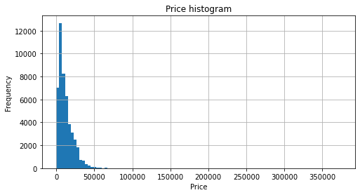

```python
vehicles_new.hist('price', bins = 100, grid = True, figsize = (8, 4))
plt.xlabel('Price')
plt.ylabel('Frequency')
plt.title('Price histogram')
plt.show()
```

```python
vehicles_new['price'].describe()
```

```
count     47899.000000
mean      12159.549281
std       10079.922175
min           1.000000
25%        5000.000000
50%        9000.000000
75%       16900.000000
max      375000.000000
Name: price, dtype: float64
```

Both the histogram and statistics data of the 'price' column shows that there are outliers on both sides of the distribution. It's clear that 75% of the cars are priced 16900 and under, and the number of cars priced over 75000 is approching zero. However, it's not clear what the distribution is like on the cheaper end. To find out, let's have a look at the 10 cheapest cars.

```python
vehicles_new.sort_values('price').head(10)
```

|  | price | model_year | model | condition | cylinders | fuel | odometer | transmission | type | paint_color | is_4wd | date_posted | days_listed | day_of_week_posted | month_posted | year_posted | vehicle_age | mileage_per_year |
| --- | --- | --- | --- | --- | --- | --- | --- | --- | --- | --- | --- | --- | --- | --- | --- | --- | --- | --- |
| 10951 | 1 | 2015 | ram 1500 | 3 | 10 | gas | 59980.0 | other | truck | silver | 1 | 2018-07-25 | 4 | 2 | 7 | 2018 | 3 | 19994.0 |
| 8804 | 1 | 2015 | ford edge | 3 | 6 | gas | 24897.0 | automatic | SUV | black | 1 | 2018-06-21 | 83 | 3 | 6 | 2018 | 3 | 8299.0 |
| 11438 | 1 | 2014 | chevrolet silverado | 4 | 8 | gas | 42.0 | automatic | truck | black | 1 | 2018-06-28 | 60 | 3 | 6 | 2018 | 4 | 11.0 |
| 38692 | 1 | 2002 | volkswagen jetta | 2 | 4 | gas | 167062.0 | automatic | sedan | blue | 0 | 2019-02-08 | 12 | 4 | 2 | 2019 | 17 | 9828.0 |
| 8702 | 1 | 2014 | gmc sierra | 3 | 8 | gas | 147470.0 | automatic | truck | brown | 0 | 2018-12-29 | 9 | 5 | 12 | 2018 | 4 | 36868.0 |
| 8664 | 1 | 2014 | chevrolet camaro | 3 | 6 | gas | 51550.0 | manual | coupe | black | 1 | 2018-07-31 | 36 | 1 | 7 | 2018 | 4 | 12888.0 |
| 8663 | 1 | 2016 | jeep wrangler | 3 | 6 | gas | 56000.0 | automatic | SUV | red | 1 | 2018-05-20 | 44 | 6 | 5 | 2018 | 2 | 28000.0 |
| 46210 | 1 | 2007 | chevrolet trailblazer | 3 | 8 | gas | 137000.0 | automatic | SUV | black | 1 | 2018-08-06 | 28 | 0 | 8 | 2018 | 11 | 12455.0 |
| 8662 | 1 | 2012 | ford mustang | 3 | 10 | gas | 41469.0 | automatic | coupe | orange | 1 | 2018-08-13 | 20 | 0 | 8 | 2018 | 6 | 6912.0 |
| 8661 | 1 | 2017 | ram 3500 | 3 | 10 | gas | 57482.0 | other | truck | white | 1 | 2019-03-17 | 3 | 6 | 3 | 2019 | 2 | 28741.0 |

It's interesting that there are so many 1 dollar cars, and these are not particularly old cars or cars have high mileage. Could that be a mistake when entering the data? Can we safely keep these out? Let's find out the proportion of these cars.

```python
len(vehicles_new.query('price == 1')) / len(vehicles_new)
```

```
0.015574437879705213
```

The cars priced exactly 1 dollar represents slightly over 1 percent of the total cars. Therefore we can consider it safe to remove these outliers on the cheaper end of the price range. Now. Let's have a look at how many cars more priced over 50000, and 75000 respectively.

```python
len(vehicles_new.query('price >= 50000'))/ len(vehicles_new)
```

```
0.004551243240986242
```

```python
len(vehicles_new.query('price >=75000')) / len(vehicles_new)
```

```
0.0005219315643332846
```

They both represent a very small percentage of the total cars. While it would be interesting to study these outliers, they also skew the data towards the more expensive end. For now, let's arbitrarily use 50000 as the upper threshhold for the data. Please note that this is still higher than the upper whisker (3rd quantile + 1.5 * IQR), which is 34750 if we used a boxplot to show the price distribution.

**Vehicle age distribution**

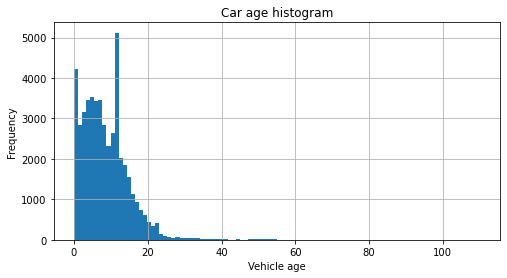

```python
vehicles_new.hist('vehicle_age', bins = 100, grid = True, figsize = (8,4))
plt.xlabel('Vehicle age')
plt.ylabel('Frequency')
plt.title('Car age histogram')
plt.show()
```

```python
vehicles_new['vehicle_age'].describe()
```

```
count    47899.000000
mean         8.549970
std          6.257531
min          0.000000
25%          4.000000
50%          7.000000
75%         12.000000
max        110.000000
Name: vehicle_age, dtype: float64
```

The distribution of the 'vehicle_age' shows two peaks, one at 0, meaning there are lots of cars on sale which are quite new, and one around 10 years. 75% of the cars are aged 12 years and under, but there are some outliers on the older side of the distribution, the oldest one being 110 years old. The distribution seems to be thinnning out to 0 after 40 years. Let's have a look at the proportion of cars older than 40 years.

```python
len(vehicles_new.query('vehicle_age > 40'))/len(vehicles_new)
```

```
0.0032986074865863587
```

Cars older than 40 years only represents a very small proportion. It's safe to remove these.

**Odometer distribution**

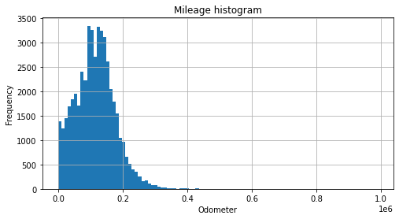

```python
vehicles_new.hist('odometer', bins = 100, grid = True, figsize = (8, 4))
plt.xlabel('Odometer')
plt.ylabel('Frequency')
plt.title('Mileage histogram')
plt.show()
```

```python
vehicles_new['odometer'].describe()
```

```
count     47899.000000
mean     115081.371135
std       62424.773267
min           0.000000
25%       72757.000000
50%      114524.000000
75%      152869.000000
max      990000.000000
Name: odometer, dtype: float64
```

As show in the graph and descriptive statistics, 75% of the cars have odometers less than 153000. After 300000, the numbers is approaching zero. There are clearly some outliers on the high odometers' end. Let's find out the proportion of cars having over 300000 odometers (3rd quantile + 1.5 * IQR is 273000).

```python
len(vehicles_new.query('odometer > 300000')) / len(vehicles_new)
```

```
0.005490720056786154
```

```python
vehicles_new.query('odometer > 300000')['vehicle_age'].describe()
```

```
count    263.000000
mean      15.433460
std        6.102366
min        0.000000
25%       12.000000
50%       15.000000
75%       19.000000
max       54.000000
Name: vehicle_age, dtype: float64
```

It's a very small proportion. A quick look at the age distribution of these high odometer cars also shows that these are not exclusively old cars only. We can consider removing these outliers.

**Cylinders**

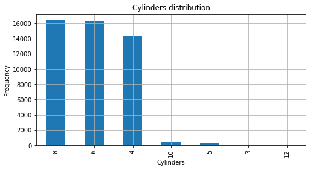

```python
vehicles_new['cylinders'].value_counts().plot(kind = 'bar', grid = True, figsize = (8, 4))
plt.xlabel('Cylinders')
plt.ylabel('Frequency')
plt.title('Cylinders distribution')
plt.show()
```

As shown in the graph, most of the cars have 4, 6, or 8 cylinders. The bar for 3 and 12 is very low and it's really hard to see. Let's find out how many cars have 3 or 12 cylinders.

```python
len(vehicles_new.query('cylinders in (3, 12)'))
```

```
35
```

Only 35!

**Car conditions**

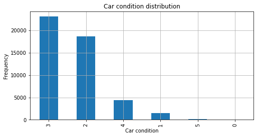

```python
vehicles_new['condition'].value_counts().plot(kind = 'bar',grid = True, figsize = (8, 4))
plt.xlabel('Car condition')
plt.ylabel('Frequency')
plt.title('Car condition distribution')
plt.show()
```

As shown above, most of the cars' condition are 3, or 2, excellent and good respectively. There are some cars that are new (5), and barely any are salvage(0)

### 4.2 Removing outliers

Given the information shown in the graphs above, let's remove the cars that are priced 1 or over 50000, older than 40 years, and have odometers of more than 300000. In order not to lose any data, we will keep the outliers in a separate dataset.

**Slicing data**

```python
vehicles_filtered = vehicles_new.query(
    'price != 1 & price <= 50000 & vehicle_age <= 40 & odometer <= 300000')
```

```python
len(vehicles_filtered)/len(vehicles_new)
```

```
0.971398150274536
```

Slightly less than 3 percent of the data is filtered out. It's reasonable. We can proceed to save the data that is filtered out in a separate dataset and use the filtered data for the following exploratory analysis.

```python
vehicles_filtered_out = vehicles_new.query(
    'price == 1 | price > 50000 | vehicle_age > 40 | odometer > 300000')
```

```python
len(vehicles_filtered_out)/len(vehicles_new)
```

```
0.028601849725463997
```

### 4.3 New graphs

Let's use the filtered data to plot new histograms. To see the comparison, we'll plot the two graphs next to each other.

**Car price**

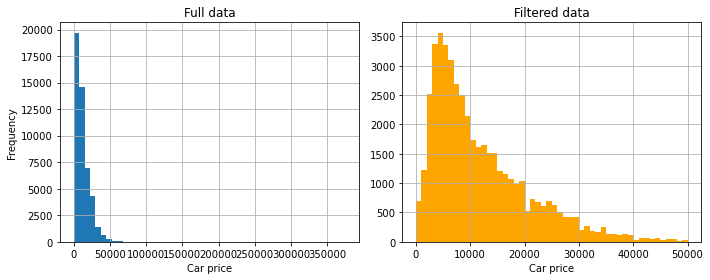

```python
fig, (ax1,ax2) = plt.subplots(1,2, figsize=(10,4))
vehicles_new['price'].hist(bins = 50, grid = True, ax = ax1)
ax1.set_title('Full data')
ax1.set_ylabel('Frequency')
ax1.set_xlabel('Car price')
vehicles_filtered['price'].hist(bins = 50, grid = True, color = 'orange',ax = ax2)
ax2.set_title('Filtered data')
ax2.set_xlabel('Car price')

plt.tight_layout()
```

Now the histogram for the filtered data is more readable. It shows the peak of the car prices just under 5000, and then the number descreases as the price goes up.

Let's plot the histograms for the vehicles' age next.

**Vehicle age**

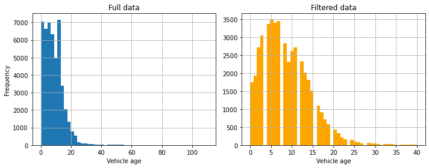

```python
fig, (ax1,ax2) = plt.subplots(1,2, figsize=(10,4))
vehicles_new['vehicle_age'].hist(bins = 50, grid = True, ax = ax1)
ax1.set_title('Full data')
ax1.set_ylabel('Frequency')
ax1.set_xlabel('Vehicle age')

vehicles_filtered['vehicle_age'].hist(bins = 50, grid = True, color = 'orange', ax = ax2)
ax2.set_title('Filtered data')
ax2.set_xlabel('Vehicle age')
plt.tight_layout()
```

The full data and filtered data exhibit different peaks. While there are 3 peaks for the full data, close 0, 8, and 12 year, the peak for the filtered data center around 4-7 years old. Did the removal of these 1 dollar cars or more expensive cars do that to the data? Let's have a look.

```python
vehicles_filtered_out['vehicle_age'].describe()
```

```
count    1370.000000
mean       10.332117
std        15.875011
min         0.000000
25%         0.000000
50%         3.000000
75%        14.000000
max       110.000000
Name: vehicle_age, dtype: float64
```

Indeed, in the filtered out data, the mean age of the cars is 10 years old. Taking these away from the data, the vehicle age distribution shows different peaks from before. We are not going to do anything for the moment but it's good to keep this in mind.

**Odometer**

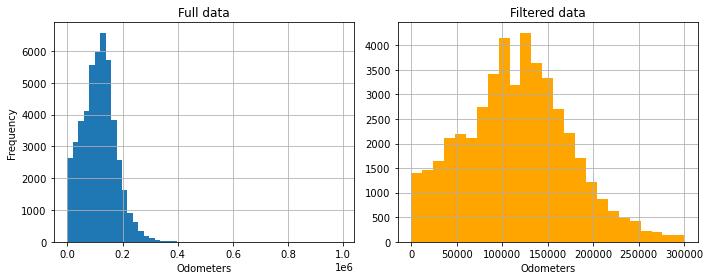

```python
fig, (ax1,ax2) = plt.subplots(1,2, figsize=(10,4))
vehicles_new['odometer'].hist(bins = 50, grid = True, ax = ax1)
ax1.set_title('Full data')
ax1.set_ylabel('Frequency')
ax1.set_xlabel('Odometers')
vehicles_filtered['odometer'].hist(bins = 25, grid = True, color = 'orange', ax = ax2)
ax2.set_title('Filtered data')
ax2.set_xlabel('Odometers')
plt.tight_layout()
```

The histogram of the mileage from the filtered data is much more readable and informative. It shows a peak around 125000, and right skewed.

**Cylinders**

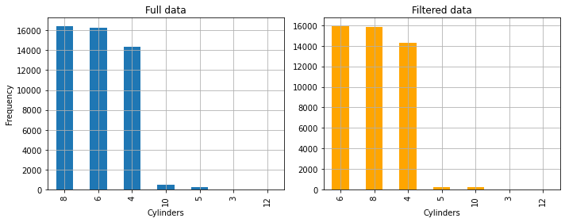

```python
fig, (ax1,ax2) = plt.subplots(1,2, figsize=(10,4))
vehicles_new['cylinders'].value_counts().plot(kind = 'bar', grid = True, ax = ax1)
ax1.set_title('Full data')
ax1.set_ylabel('Frequency')
ax1.set_xlabel('Cylinders')

vehicles_filtered['cylinders'].value_counts().plot(
    kind = 'bar', grid = True, color = 'orange', ax = ax2)
ax2.set_title('Filtered data')
ax2.set_xlabel('Cylinders')
plt.tight_layout()
```

Filtering the data changed the ranking postion of 6 and 8, as well as 5 and 10. This indicates that most of the cars filtered out have 8 cylinders.

**Car condition**

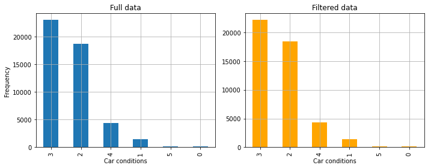

```python
fig, (ax1,ax2) = plt.subplots(1,2, figsize=(10,4))
vehicles_new['condition'].value_counts().plot(kind = 'bar', grid = True, ax = ax1)
ax1.set_title('Full data')
ax1.set_ylabel('Frequency')
ax1.set_xlabel('Car conditions')

vehicles_filtered['condition'].value_counts().plot(
    kind = 'bar', grid = True, color = 'orange', ax = ax2)
ax2.set_title('Filtered data')
ax2.set_xlabel('Car conditions')
plt.tight_layout()
```

The distribution of the car conditions didn't change much, which is great! The cars that dominate are still **good** and **excellent**!

### 4.4 Life span of car advertisements

In this section, we will study how many days advertisements were displayed (days_listed) and describe the typical lifetime of an ad. We will also take a closer look at what kind of cars were removed quickly, and what kind were listed for an abnormally long time.

Just to be sure that, by filtering the data, we didn't change the distribution of this parameter dramatically, let's plot two histograms for 'days_listed', using the full dataset, and the filtered dataset.

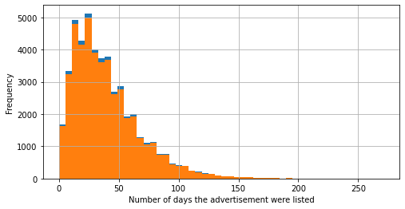

```python
vehicles_new['days_listed'].hist(bins = 50, figsize = (8, 4))
vehicles_filtered['days_listed'].hist(bins = 50, figsize = (8, 4))
plt.xlabel('Number of days the advertisement were listed')
plt.ylabel('Frequency')
plt.show()
```

Filtering the data didn't seem to change the distribution of 'days_listed' much, which is good news.

```python
vehicles_filtered['days_listed'].describe()
```

```
count    46529.000000
mean        39.571901
std         28.200632
min          0.000000
25%         19.000000
50%         33.000000
75%         53.000000
max        271.000000
Name: days_listed, dtype: float64
```

Using the filtered dataset, the mean for days listed is approximately 39 days, and the median 33 days. 75% of the ads were listed 53 days and under. This indicates that the typical life of a car ad is slightly over a month but less than 2 months.

Taking a look at the extreme ends of the ad life: the longest ad life is 271 days, whereas there seems to be a lot of ads which lasted less than one day! From the graph we can also see that the numbers start to thin out fast after 150.

Let's find out which cars have the days listed as 0, which ones have less than 7 days, which ones were listed over 150 days, and which car has the longest listing days.

**Zero day listings**

```python
vehicles_filtered.query('days_listed == 0').head()
```

|  | price | model_year | model | condition | cylinders | fuel | odometer | transmission | type | paint_color | is_4wd | date_posted | days_listed | day_of_week_posted | month_posted | year_posted | vehicle_age | mileage_per_year |
| --- | --- | --- | --- | --- | --- | --- | --- | --- | --- | --- | --- | --- | --- | --- | --- | --- | --- | --- |
| 1165 | 14995 | 2008 | chevrolet silverado 1500 | 3 | 8 | gas | 93300.0 | automatic | truck | grey | 1 | 2018-05-15 | 0 | 1 | 5 | 2018 | 10 | 9330.0 |
| 1854 | 14000 | 1999 | ford f250 | 3 | 8 | diesel | 137500.0 | automatic | truck | red | 1 | 2018-09-27 | 0 | 3 | 9 | 2018 | 19 | 7237.0 |
| 2707 | 4000 | 2004 | ram 1500 | 3 | 8 | gas | 250000.0 | automatic | truck | brown | 1 | 2018-08-13 | 0 | 0 | 8 | 2018 | 14 | 17858.0 |
| 3702 | 16750 | 1985 | chevrolet corvette | 4 | 8 | gas | 24540.0 | automatic | hatchback | white | 0 | 2018-10-14 | 0 | 6 | 10 | 2018 | 33 | 744.0 |
| 4254 | 5000 | 2007 | toyota corolla | 2 | 4 | gas | 223000.0 | manual | sedan | silver | 0 | 2018-07-11 | 0 | 2 | 7 | 2018 | 11 | 20273.0 |

```python
len(vehicles_filtered.query('days_listed == 0'))
```

```
49
```

There doesn't seem to be any particular pattern among the car ads that didn't last even for a day. Could this be a mistake?

In a real life situation, this would need to be brought to attention to the team who provided the data for further information. Fow the purpose of this report, let's have a look at ads that lastes more than 0 but gone within a week. We will artitrarily decide these are the ones that are gone quickly.

**Cars with short advertisement life**

```python
vehicles_filtered.query('0 < days_listed <= 7')
```

|  | price | model_year | model | condition | cylinders | fuel | odometer | transmission | type | paint_color | is_4wd | date_posted | days_listed | day_of_week_posted | month_posted | year_posted | vehicle_age | mileage_per_year |
| --- | --- | --- | --- | --- | --- | --- | --- | --- | --- | --- | --- | --- | --- | --- | --- | --- | --- | --- |
| 30 | 9499 | 2015 | nissan altima | 4 | 4 | gas | 51848.0 | automatic | sedan | grey | 0 | 2018-11-12 | 7 | 0 | 11 | 2018 | 3 | 17283.0 |
| 37 | 8000 | 2009 | ford f-150 | 2 | 8 | gas | 234000.0 | automatic | truck | black | 1 | 2019-03-31 | 1 | 6 | 3 | 2019 | 10 | 23400.0 |
| 57 | 5200 | 2006 | toyota highlander | 2 | 6 | gas | 186000.0 | automatic | SUV | green | 0 | 2018-12-20 | 2 | 3 | 12 | 2018 | 12 | 15500.0 |
| 70 | 6950 | 2005 | chevrolet tahoe | 3 | 8 | gas | 186021.0 | automatic | SUV | black | 1 | 2018-10-30 | 3 | 1 | 10 | 2018 | 13 | 14310.0 |
| 111 | 33900 | 2018 | chevrolet silverado 1500 crew | 2 | 8 | gas | 11315.0 | other | pickup | white | 1 | 2019-03-01 | 2 | 4 | 3 | 2019 | 1 | 11315.0 |
| ... | ... | ... | ... | ... | ... | ... | ... | ... | ... | ... | ... | ... | ... | ... | ... | ... | ... | ... |
| 47792 | 12990 | 2013 | honda accord | 3 | 6 | gas | 118659.0 | automatic | coupe | red | 0 | 2018-05-02 | 6 | 2 | 5 | 2018 | 5 | 23732.0 |
| 47830 | 4700 | 2007 | toyota corolla | 3 | 4 | gas | 137000.0 | automatic | sedan | grey | 0 | 2018-07-17 | 6 | 1 | 7 | 2018 | 11 | 12455.0 |
| 47858 | 7300 | 2016 | ford fusion se | 3 | 4 | gas | 106212.0 | automatic | sedan | grey | 0 | 2019-03-10 | 6 | 6 | 3 | 2019 | 3 | 35404.0 |
| 47870 | 9500 | 2012 | chevrolet traverse | 2 | 6 | gas | 144500.0 | automatic | SUV | silver | 1 | 2019-03-05 | 1 | 1 | 3 | 2019 | 7 | 20643.0 |
| 47879 | 20481 | 2018 | toyota camry | 4 | 4 | gas | 38590.0 | automatic | sedan | silver | 0 | 2018-12-06 | 4 | 3 | 12 | 2018 | 0 | inf |

2767 rows × 18 columns

```python
vehicles_filtered.query('0 < days_listed <= 7').describe()
```

|  | price | model_year | condition | cylinders | odometer | is_4wd | days_listed | day_of_week_posted | month_posted | year_posted | vehicle_age | mileage_per_year |
| --- | --- | --- | --- | --- | --- | --- | --- | --- | --- | --- | --- | --- |
| count | 2767.000000 | 2767.000000 | 2767.000000 | 2767.000000 | 2767.00000 | 2767.000000 | 2767.000000 | 2767.000000 | 2767.000000 | 2767.000000 | 2767.000000 | 2767.0 |
| mean | 12239.842429 | 2009.870618 | 2.659198 | 6.089989 | 115186.95627 | 0.491507 | 4.790025 | 2.946151 | 6.728948 | 2018.295266 | 8.424648 | inf |
| std | 9076.218664 | 5.729176 | 0.725933 | 1.631508 | 58478.01055 | 0.500018 | 1.835321 | 1.989577 | 3.506255 | 0.456245 | 5.726536 | NaN |
| min | 5.000000 | 1978.000000 | 0.000000 | 3.000000 | 0.00000 | 0.000000 | 1.000000 | 0.000000 | 1.000000 | 2018.000000 | 0.000000 | 0.0 |
| 25% | 5495.000000 | 2006.000000 | 2.000000 | 4.000000 | 73661.50000 | 0.000000 | 3.000000 | 1.000000 | 4.000000 | 2018.000000 | 4.000000 | 11129.0 |
| 50% | 9500.000000 | 2011.000000 | 3.000000 | 6.000000 | 116510.00000 | 0.000000 | 5.000000 | 3.000000 | 7.000000 | 2018.000000 | 7.000000 | 15657.0 |
| 75% | 16987.500000 | 2014.000000 | 3.000000 | 8.000000 | 153000.00000 | 1.000000 | 6.000000 | 5.000000 | 10.000000 | 2019.000000 | 12.000000 | 22000.0 |
| max | 49750.000000 | 2019.000000 | 5.000000 | 10.000000 | 300000.00000 | 1.000000 | 7.000000 | 6.000000 | 12.000000 | 2019.000000 | 40.000000 | inf |

There are 2767 car ads which are gone within a week. Let's check out the characteristics of these cars in terms of 'price', 'model_year', 'model', 'odometer', 'condition', 'transmission' and 'color', in comparision with the whole data.

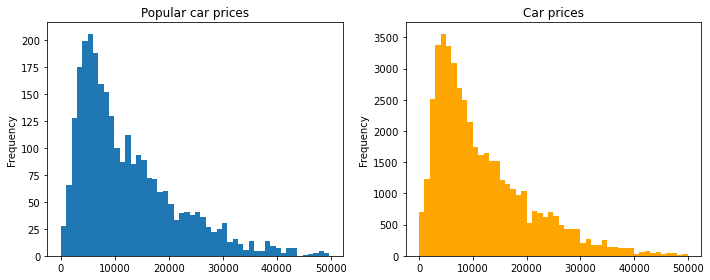

```python
fig, (ax1,ax2) = plt.subplots(1,2, figsize=(10,4))
vehicles_filtered.query('0 < days_listed <= 7')['price'].plot(
    kind = 'hist', bins = 50, title = 'Popular car prices', ax=ax1)
vehicles_filtered['price'].plot(kind = 'hist', bins = 50, color = 'orange',
                                title = 'Car prices',ax=ax2)
plt.tight_layout()
```

```python
print('Popular car price median:',
      vehicles_filtered.query('0 < days_listed <= 7')['price'].median())
print('Popular car price mean:',
      vehicles_filtered.query('0 < days_listed <= 7')['price'].mean())
print('Car price median:', vehicles_filtered['price'].median())
print('Car price mean:', vehicles_filtered['price'].mean())
```

```
Popular car price median: 9500.0
Popular car price mean: 12239.842428623058
Car price median: 9495.0
Car price mean: 12109.173805583614
```

The price distribution of the popular cars is almost identical with that of all cars. There is not much difference in the mean and median price for popular cars and for all cars either. Price doesn't seem to be a deciding factor for car popularity!

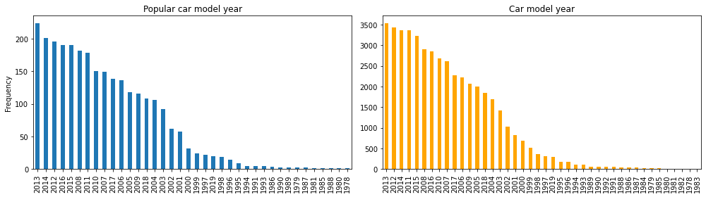

```python
fig, (ax1,ax2) = plt.subplots(1,2, figsize=(14,4))
vehicles_filtered.query('0 < days_listed <= 7')['model_year'].value_counts().plot(
    kind = 'bar', title = 'Popular car model year', ax=ax1)
ax1.set_ylabel('Frequency')
vehicles_filtered['model_year'].value_counts().plot(
    kind = 'bar', title = 'Car model year', color = 'orange', ax=ax2)
plt.tight_layout()
```

The distribution is almost identical. The top three popular car model years are 2013, 2014, and 2012, which are the same as the top three year models among all cars, just in slightly different oder.

It seems that how old a car is doesn't affect its popularity. Let's have a look at the odometer next.

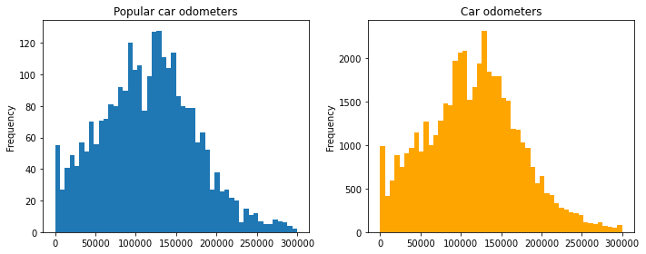

```python
fig, (ax1,ax2) = plt.subplots(1,2, figsize=(10,4))
vehicles_filtered.query('0 < days_listed <= 7')['odometer'].plot(
    kind = 'hist', bins = 50, title = 'Popular car odometers', ax=ax1)
vehicles_filtered['odometer'].plot(kind = 'hist', bins = 50,
                                   title = 'Car odometers', color = 'orange', ax=ax2)
plt.tight_layout()
```

Interestingly, odometer also doesn't seem to be impacting factor. Let's have a look at condition then.

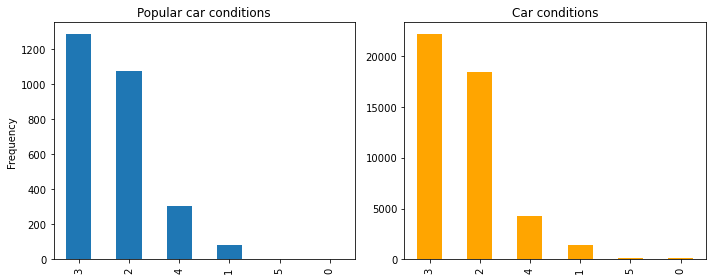

```python
fig, (ax1,ax2) = plt.subplots(1,2, figsize=(10,4))
vehicles_filtered.query('0 < days_listed <= 7')['condition'].value_counts().plot(
    kind = 'bar', title = 'Popular car conditions', ax=ax1)
ax1.set_ylabel('Frequency')

vehicles_filtered['condition'].value_counts().plot(
    title = 'Car conditions', kind = 'bar', color = 'orange', ax=ax2)
plt.tight_layout()
```

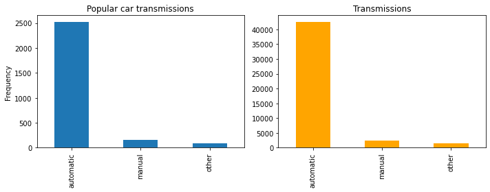

```python
fig, (ax1,ax2) = plt.subplots(1,2, figsize=(10,4))
vehicles_filtered.query('0 < days_listed <= 7')['transmission'].value_counts().plot(
    title = 'Popular car transmissions', kind = 'bar', ax=ax1)
ax1.set_ylabel('Frequency')
vehicles_filtered['transmission'].value_counts().plot(
    kind = 'bar', title = 'Transmissions', color = 'orange', ax=ax2)
plt.tight_layout()
```

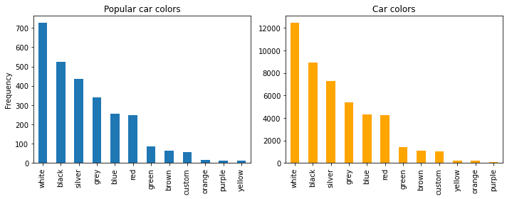

```python
fig, (ax1,ax2) = plt.subplots(1,2, figsize=(10,4))
vehicles_filtered.query('0 < days_listed <= 7')['paint_color'].value_counts().plot(
    kind = 'bar', title= 'Popular car colors', ax=ax1)
ax1.set_ylabel('Frequency')
vehicles_filtered['paint_color'].value_counts().plot(
    kind = 'bar', color = 'orange', title = 'Car colors', ax=ax2)
plt.tight_layout()
```

All the graphing for not much! There is indeed nothing standing out for those cars that were quickly removed!

Now let's have a look at the car ad that have stayed for over 150 days.

**Cars of long advertisement life**

```python
vehicles_filtered.query('days_listed > 150')
```

|  | price | model_year | model | condition | cylinders | fuel | odometer | transmission | type | paint_color | is_4wd | date_posted | days_listed | day_of_week_posted | month_posted | year_posted | vehicle_age | mileage_per_year |
| --- | --- | --- | --- | --- | --- | --- | --- | --- | --- | --- | --- | --- | --- | --- | --- | --- | --- | --- |
| 49 | 3800 | 2012 | ford focus | 2 | 4 | gas | 130323.0 | automatic | sedan | black | 0 | 2018-11-29 | 261 | 3 | 11 | 2018 | 6 | 21721.0 |
| 83 | 18800 | 2015 | chevrolet camaro lt coupe 2d | 2 | 6 | gas | 33926.0 | other | coupe | grey | 0 | 2019-01-16 | 152 | 2 | 1 | 2019 | 4 | 8482.0 |
| 211 | 8795 | 2014 | honda civic | 3 | 4 | gas | 85452.0 | automatic | sedan | grey | 0 | 2018-09-11 | 164 | 1 | 9 | 2018 | 4 | 21363.0 |
| 647 | 26995 | 2016 | chevrolet silverado | 4 | 8 | gas | 36645.0 | automatic | pickup | white | 1 | 2018-09-01 | 152 | 5 | 9 | 2018 | 2 | 18323.0 |
| 797 | 8595 | 2014 | dodge charger | 4 | 6 | gas | 100004.0 | automatic | sedan | blue | 0 | 2018-10-14 | 154 | 6 | 10 | 2018 | 4 | 25001.0 |
| ... | ... | ... | ... | ... | ... | ... | ... | ... | ... | ... | ... | ... | ... | ... | ... | ... | ... | ... |
| 47338 | 9995 | 2012 | toyota tacoma | 3 | 6 | gas | 172695.0 | automatic | truck | grey | 0 | 2018-09-19 | 162 | 2 | 9 | 2018 | 6 | 28783.0 |
| 47465 | 8495 | 2013 | hyundai elantra | 2 | 4 | gas | 55262.0 | automatic | sedan | blue | 0 | 2018-06-30 | 158 | 5 | 6 | 2018 | 5 | 11053.0 |
| 47711 | 3500 | 2005 | toyota camry | 3 | 4 | gas | 208299.0 | automatic | sedan | green | 0 | 2018-06-07 | 159 | 3 | 6 | 2018 | 13 | 16023.0 |
| 47864 | 1200 | 2005 | volkswagen jetta | 1 | 5 | gas | 185000.0 | automatic | sedan | grey | 0 | 2018-10-10 | 158 | 2 | 10 | 2018 | 13 | 14231.0 |
| 47877 | 7995 | 2011 | chevrolet equinox | 4 | 4 | gas | 111088.0 | automatic | SUV | black | 0 | 2019-04-01 | 175 | 0 | 4 | 2019 | 8 | 13886.0 |

218 rows × 18 columns

There are 218 car ads fitting the criterion.

Now let's compare the parameters between those cars and all cars.

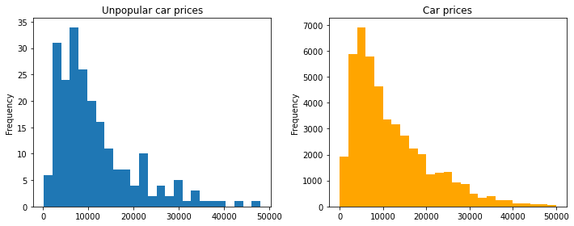

```python
fig, (ax1,ax2) = plt.subplots(1,2, figsize=(10,4))
vehicles_filtered.query('days_listed >150')['price'].plot(
    kind = 'hist', bins = 25, title = 'Unpopular car prices', ax=ax1)
vehicles_filtered['price'].plot(kind = 'hist', bins = 25, color = 'orange',
                                title = 'Car prices', ax=ax2)
plt.tight_layout()
```

Compared to the price distribution for all cars, there seems to be a peak for not so popular car prices around 3000, then again around 6000. Let's take a look at the mean and median prices for both groups.

```python
print('Unpopular car price median:',
      vehicles_filtered.query('days_listed > 150')['price'].median())
print('Unpopular car price mean:',
      vehicles_filtered.query('days_listed > 150')['price'].mean())
print('Car price median:', vehicles_filtered['price'].median())
print('Car price mean:', vehicles_filtered['price'].mean())
```

```
Unpopular car price median: 8745.0
Unpopular car price mean: 11441.188073394496
Car price median: 9495.0
Car price mean: 12109.173805583614
```

While the price distributions for both groups are similar, the unpopular cars have a slightly lower median and mean prices compared with these for all the cars.

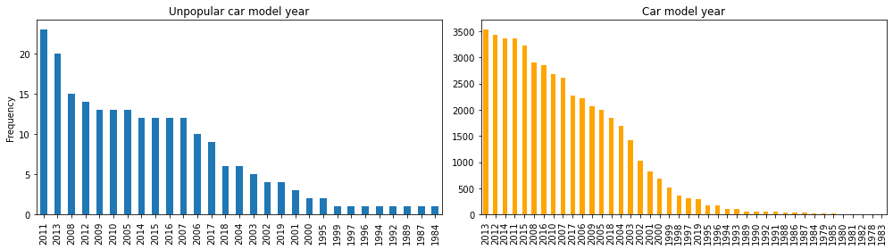

```python
fig, (ax1,ax2) = plt.subplots(1,2, figsize=(14,4))
vehicles_filtered.query('days_listed >150')['model_year'].value_counts().plot(
    kind = 'bar', title = 'Unpopular car model year', ax=ax1)
ax1.set_ylabel('Frequency')
vehicles_filtered['model_year'].value_counts().plot(
    kind = 'bar', color = 'orange', title = 'Car model year', ax=ax2)
plt.tight_layout()
```

The top 5 unpopular car model years are 2011, 2013, 2008, 2012, and 2009, slightly different from the top 5 car model years: 2013, 2012, 2014, 2011, and 2015.

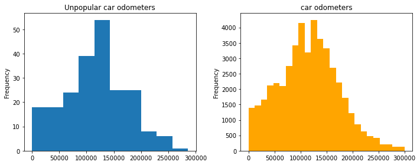

```python
fig, (ax1,ax2) = plt.subplots(1,2, figsize=(10,4))
vehicles_filtered.query('days_listed > 150')['odometer'].plot(
    kind = 'hist', bins = 10, title = 'Unpopular car odometers', ax=ax1)
vehicles_filtered['odometer'].plot(kind = 'hist', bins = 25,
                                   title = 'car odometers', color = 'orange', ax=ax2)
plt.tight_layout()
```

```python
print('Unpopular car odometer median:',
      vehicles_filtered.query('days_listed > 150')['odometer'].median())
print('Unpopular car odometer mean:',
      vehicles_filtered.query('days_listed > 150')['odometer'].mean())
print('Car odometer median:', vehicles_filtered['odometer'].median())
print('Car odometer mean:', vehicles_filtered['odometer'].mean())
```

```
Unpopular car odometer median: 118610.0
Unpopular car odometer mean: 116514.9495412844
Car odometer median: 116000.0
Car odometer mean: 115287.79697607944
```

As show in both graphs and the median and mean statistics, the odometers of the unpopular cars do not differ much from cars in general.

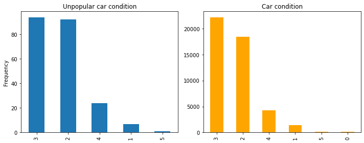

```python
fig, (ax1,ax2) = plt.subplots(1,2, figsize=(10,4))
vehicles_filtered.query('days_listed >150')['condition'].value_counts().plot(
    kind = 'bar', title = 'Unpopular car condition', ax=ax1)
ax1.set_ylabel('Frequency')
vehicles_filtered['condition'].value_counts().plot(
    kind = 'bar', color = 'orange', title = 'Car condition', ax=ax2)
plt.tight_layout()
```

The top 2 conditions are 3 and 2, excellent and good, which is the same to distribution of car conditions over all. The only difference is that there is no condition '0' in the unpopular cars, which is the worse conditio of all. It's interesting to see that the car conditions doesn't impact much on the car popularity either.

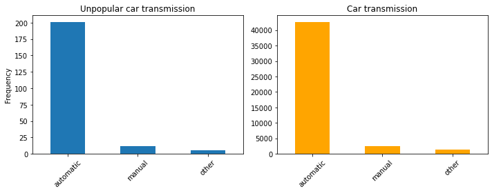

```python
fig, (ax1,ax2) = plt.subplots(1,2, figsize=(10,4))
vehicles_filtered.query('days_listed >150')['transmission'].value_counts().plot(
    kind = 'bar', title = 'Unpopular car transmission', ax=ax1)
ax1.set_ylabel('Frequency')
ax1.set_xticklabels(ax1.get_xticklabels(), rotation= 45)

vehicles_filtered['transmission'].value_counts().plot(
    kind = 'bar', color = 'orange', title = 'Car transmission', ax=ax2)
ax2.set_xticklabels(ax2.get_xticklabels(), rotation= 45)
plt.tight_layout()
```

Both groups show almost identitical distribution for car transmissions! Let's have a look at the last variable, color!

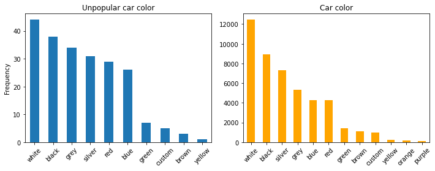

```python
fig, (ax1,ax2) = plt.subplots(1,2, figsize=(10,4))
vehicles_filtered.query('days_listed >150')['paint_color'].value_counts().plot(
    kind = 'bar', title = 'Unpopular car color', ax=ax1)
ax1.set_xticklabels(ax1.get_xticklabels(), rotation= 45)
ax1.set_ylabel('Frequency')

vehicles_filtered['paint_color'].value_counts().plot(
    kind = 'bar', color = 'orange', title = 'Car color', ax=ax2)
ax2.set_xticklabels(ax2.get_xticklabels(), rotation= 45)

plt.tight_layout()
```

White and black dominate both groups, with grey and silver swapping places.

### Conclusion

After we sorted out the cars by the number of days they were listed, we plotted the variables for both the popular ones (those that are gone within a week), and the unpopular ones(those have stayed over 150 days), and compared the pattern in these with all cars.

Suprisingly, or not, no particular pattern really stands out for both the popular and unpopular cars, except that there seems to be a lot of cars around the price of 3000 that stay longer on the listing than others.

Well, at least we now know that it is not likely that we can predict the length of time that a car ad stays on the list based on its characteristics, but what about price? Can we predict that? We will address this query in the last section of this report.

### 4.5 Number of ads and mean price by car type

In this section, we will analyze the number of ads and the average price for each type of vehicle. A graph will be plotted to show the dependence of the number of ads on the vehicle type. We will also find out which two types have the greatest number of ads.

Let's first use pivot_table to calcuate the number of ads and mean price for each type of car. We will sort the table in ascending order of the number of ads.

```python
vehicles_type = vehicles_filtered.pivot_table(
    index = 'type', values = 'price', aggfunc = ['count', 'mean'])
vehicles_type.columns = ('number_of_ads', 'mean_price')
vehicles_type = vehicles_type.sort_values('number_of_ads')
vehicles_type
```

| type | number_of_ads | mean_price |
| --- | --- | --- |
| bus | 24 | 17135.666667 |
| offroad | 201 | 14129.855721 |
| other | 229 | 10661.296943 |
| convertible | 374 | 12674.647059 |
| van | 573 | 10504.680628 |
| hatchback | 962 | 6957.200624 |
| mini-van | 1069 | 8067.755847 |
| wagon | 1423 | 9095.635278 |
| coupe | 1982 | 14268.399092 |
| pickup | 6355 | 15948.229583 |
| truck | 11017 | 16720.881184 |
| sedan | 11136 | 7063.282058 |
| SUV | 11184 | 11285.182761 |

Now let's plot the number and price.

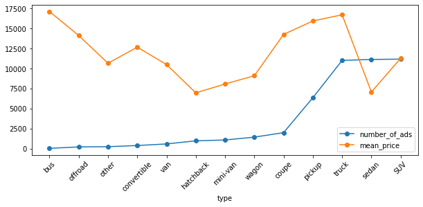

```python
vehicles_type.plot(style = 'o-', figsize = (10, 4))
plt.xticks(rotation=45)
plt.xticks(np.arange(len(vehicles_type.index)), vehicles_type.index)
plt.show()
```

As shown in the graph above, *SUV* tops the list in its number of ads, followed by *sedan*. Now let's have a look at what factors impact their car prices most.

### 4.6 Factors in car prices

In this section, we will first generate the correlation efficients for price and the numerical variables including age, mileage, and condition. Then we will make a scatterplot for each to show their relationship with prices.

For categorical variables (transmission type and color), a boxplot will be made to show their relationship with price.

**Correlation coefficients**

```python
vehicles_filtered.query('type == "SUV"')[[
    'price','vehicle_age', 'odometer', 'condition']].corr()
```

|  | price | vehicle_age | odometer | condition |
| --- | --- | --- | --- | --- |
| price | 1.000000 | -0.648791 | -0.612848 | 0.294974 |
| vehicle_age | -0.648791 | 1.000000 | 0.632784 | -0.332079 |
| odometer | -0.612848 | 0.632784 | 1.000000 | -0.347473 |
| condition | 0.294974 | -0.332079 | -0.347473 | 1.000000 |

```python
vehicles_filtered.query('type == "sedan"')[[
    'price','vehicle_age', 'odometer', 'condition']].corr()
```

|  | price | vehicle_age | odometer | condition |
| --- | --- | --- | --- | --- |
| price | 1.000000 | -0.671924 | -0.608063 | 0.311434 |
| vehicle_age | -0.671924 | 1.000000 | 0.629729 | -0.310252 |
| odometer | -0.608063 | 0.629729 | 1.000000 | -0.348089 |
| condition | 0.311434 | -0.310252 | -0.348089 | 1.000000 |

**Heatmap to show the correlations**

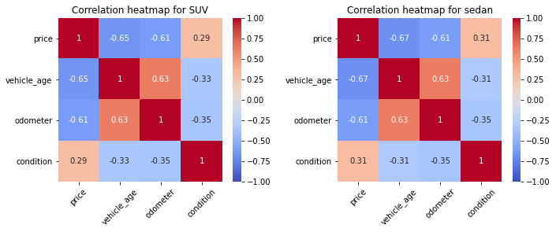

```python
fig, (ax1,ax2) = plt.subplots(1,2, figsize=(10,4))

sns.heatmap(vehicles_filtered.query('type == "SUV"')[[
    'price','vehicle_age', 'odometer', 'condition']].corr(),
            annot = True, fmt='.2g', vmin=-1, vmax=1,
            center= 0,cmap = 'coolwarm', square = True, ax = ax1)
ax1.set_title('Correlation heatmap for SUV')
ax1.set_xticklabels(ax1.get_xticklabels(), rotation= 45)

sns.heatmap(vehicles_filtered.query('type == "sedan"')[[
    'price','vehicle_age', 'odometer', 'condition']].corr(),
            annot = True, fmt='.2g', vmin=-1, vmax=1,
            center= 0,cmap = 'coolwarm', square = True, ax = ax2)
ax2.set_title('Correlation heatmap for sedan')
ax2.set_xticklabels(ax2.get_xticklabels(), rotation= 45)

plt.tight_layout()
```

The above numbers show that, for both SUVs and sedans, car prices have relatively strong negative relationship with their age, and total mileage, whereas their relationship with car's condition is not as strong. Let's take a closer look at the scatterplot of each of these pairs.

**Price and vehicle age**

Give the large number of data, let's use both *hexbin* and *scatterplot* to depict the relationship among the data.

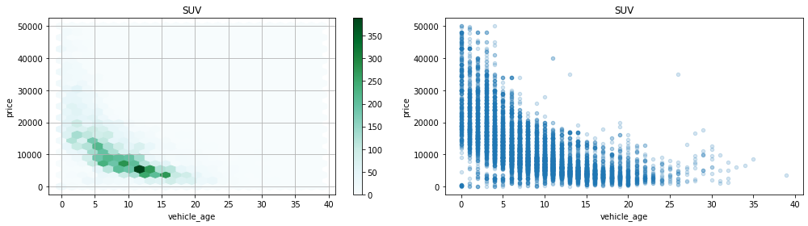

```python
fig, (ax1,ax2) = plt.subplots(1,2, figsize=(14,4))
vehicles_filtered.query('type == "SUV"').plot(
    x = 'vehicle_age', y = 'price', kind = 'hexbin',
    gridsize=25, sharex=False, grid=True, title = 'SUV', ax = ax1)
vehicles_filtered.query('type == "SUV"').plot(
    x = 'vehicle_age', y = 'price', kind = 'scatter', title = 'SUV', alpha = 0.2, ax = ax2)
plt.tight_layout()
```

The graphs above show that, as SUV cars get older, not only the price overall decreases, the range of prices also become smaller.

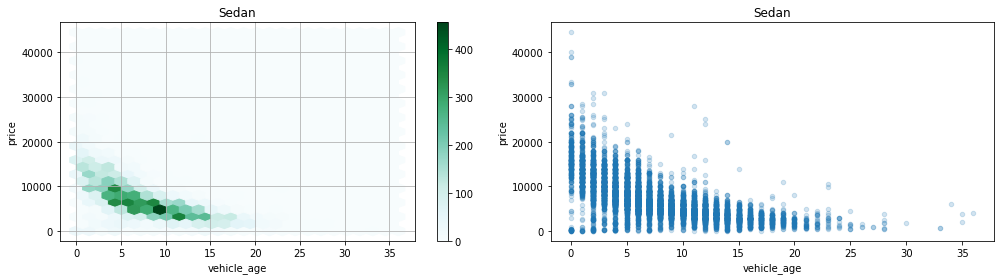

```python
fig, (ax1,ax2) = plt.subplots(1,2, figsize=(14,4))
vehicles_filtered.query('type == "sedan"').plot(
    x = 'vehicle_age', y = 'price', kind = 'hexbin',
    gridsize=25, sharex=False, grid=True, title = 'Sedan', ax = ax1)
vehicles_filtered.query('type == "sedan"').plot(
    x = 'vehicle_age', y = 'price', kind = 'scatter', title = 'Sedan', alpha = 0.2, ax = ax2)
plt.tight_layout()
```

Sedans show a similar patter as SUV, with overall cheaper prices, and younger car age.

**Price and odometers**

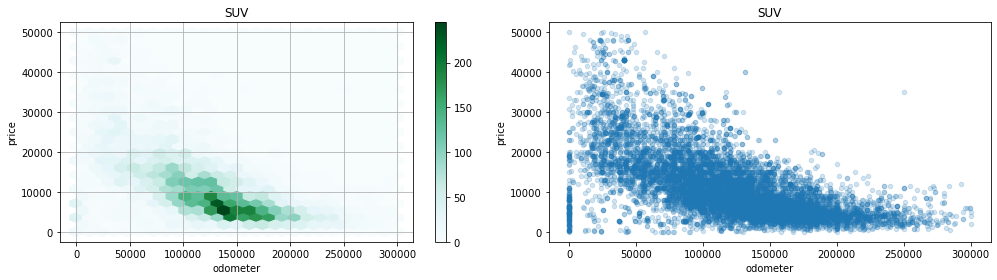

```python
fig, (ax1,ax2) = plt.subplots(1,2, figsize=(14,4))
vehicles_filtered.query('type == "SUV"').plot(
    x = 'odometer', y = 'price', kind = 'hexbin',
    gridsize=25, sharex=False, grid=True, title = 'SUV', ax = ax1)
vehicles_filtered.query('type == "SUV"').plot(
    x = 'odometer', y = 'price', kind = 'scatter', title = 'SUV', alpha = 0.2, ax = ax2)
plt.tight_layout()
```

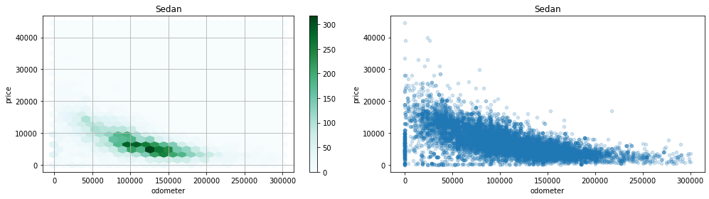

```python
fig, (ax1,ax2) = plt.subplots(1,2, figsize=(14,4))
vehicles_filtered.query('type == "sedan"').plot(
    x = 'odometer', y = 'price', kind = 'hexbin',
    gridsize=25, sharex=False, grid=True, title = 'Sedan', ax = ax1)
vehicles_filtered.query('type == "sedan"').plot(
    x = 'odometer', y = 'price', kind = 'scatter', title = 'Sedan', alpha = 0.2, ax = ax2)
plt.tight_layout()
```

For both SUV and sedan cars, the graphs show a moderately strong negative correlation between prices and their total mileage. This makes sense, the older a car is, the cheaper it might sell.

**Price and car conditions**

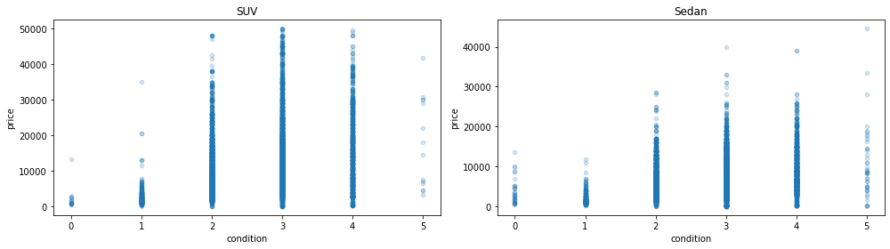

```python
fig, (ax1,ax2) = plt.subplots(1,2, figsize=(14,4))
vehicles_filtered.query('type == "SUV"').plot(
    x = 'condition', y = 'price', kind = 'scatter', title = 'SUV', alpha = 0.2, ax = ax1)
vehicles_filtered.query('type == "sedan"').plot(
    x = 'condition', y = 'price', kind = 'scatter', title = 'Sedan', alpha = 0.2, ax = ax2)
plt.tight_layout()
```

The graphs show that cars of both **SUV** and **sedan** type cluster around condition 2, 3, 4, which correspond to **good, excellent, like new**, and the prices for these car have a wide range.

Cars of condition 0 and 1, which are salvage and poor, are at the lower end of the price range. There are not as many new cars and but their prices seem to vary.

**Price and transmission types**

Before we plot the prices for different transmission types and colors, let's check how many ads there are in each category.

```python
vehicles_filtered.query('type == "SUV"')['transmission'].value_counts()
```

```
automatic    10629
manual         468
other           87
Name: transmission, dtype: int64
```

```python
vehicles_filtered.query('type == "sedan"')['transmission'].value_counts()
```

```
automatic    10518
manual         547
other           71
Name: transmission, dtype: int64
```

```python
vehicles_filtered.query('type == "SUV"')['paint_color'].value_counts()
```

```
black     3020
white     2004
silver    1865
grey      1254
blue      1034
red        836
green      432
brown      326
custom     259
orange      73
yellow      44
purple      37
Name: paint_color, dtype: int64
```

```python
vehicles_filtered.query('type == "sedan"')['paint_color'].value_counts()
```

```
silver    2769
black     2259
grey      1953
white     1378
blue      1189
red        861
custom     246
brown      236
green      191
purple      25
yellow      21
orange       8
Name: paint_color, dtype: int64
```

For SUVs, yellow and purple cars have less than 50 in number, and for sedans, purple, yellow, and orange has less than 50. The boxplot wouldn't work for these categories and therefore let's remove these before the plotting.

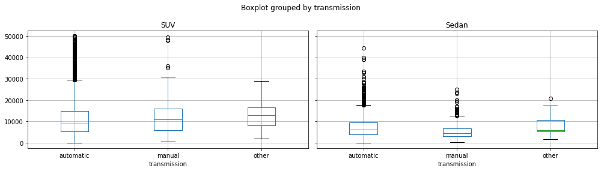

```python
fig, (ax1,ax2) = plt.subplots(1,2, figsize=(14,4), sharey = True)
vehicles_filtered.query('type == "SUV"').boxplot(
    column = 'price', by = 'transmission', ax = ax1)
ax1.set_title('SUV')
vehicles_filtered.query('type == "sedan"').boxplot(
    column = 'price', by = 'transmission', ax = ax2)
ax2.set_title('Sedan')
plt.tight_layout()
```

As shown in the graphs above, for the **SUV** type, manual cars have slightly higher median prices than automatic cars, whereas *other* have higher median prices than manual SUVs. It would be interesting to find out what *other* means. Automatic SUVs also have a lot of outliers towards the higher end of the price range.

In comparison, the median prices for automatic **sedans** are more expensive then manual sedans, with both transmission types having a rather dense distribution of outliers towards the higher price end. Similar to SUVs, *other* transmission type also has a higher median price than the other two types.

The IQR for sedans, shown as the boxes in the boxplots, are narrower than that for SUVs across all transmission types. This indicates that sedans prices have less dispersion than SUV prices.

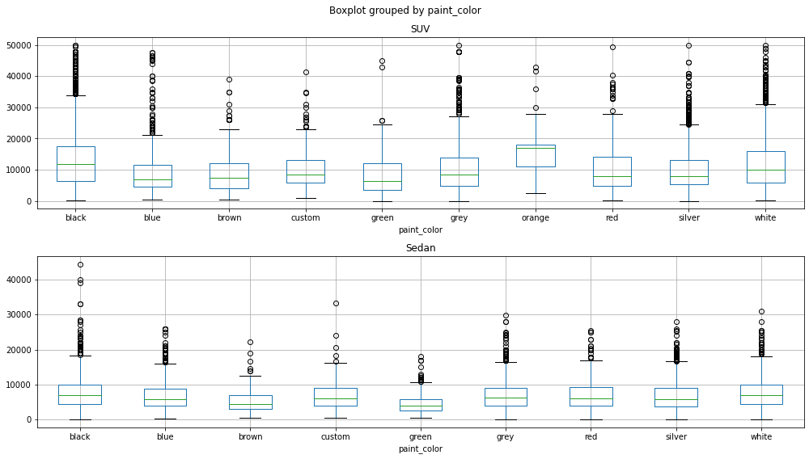

```python
fig, (ax1,ax2) = plt.subplots(2,1, figsize=(14,8))
vehicles_filtered.query(
    'type == "SUV" & paint_color not in ("purple", "yellow")').boxplot(
    column = 'price', by = 'paint_color', ax = ax1)

vehicles_filtered.query(
    'type == "sedan" & paint_color not in ("orange", "purple", "yellow")').boxplot(
    column = 'price', by = 'paint_color', ax = ax2)
ax1.set_title('SUV')
ax2.set_title('Sedan')
plt.tight_layout()
```

For **SUVs**, orange cars have the highest median price, followed by black and white cars. However it needs to be pointed out that there are only a total of 73 orange cars. Green SUVs have the lowest median price. Black and white SUVs also have quite densely distributed outliers over the upper whisker. Overall the car prices are right skewed.

For **sedans**, black, custom, grey, red, silder and white have relatively higher median prices than the others. Green sedans have the lowest median price. Similar to SUVs, the prices for all colors are right skewed. However, the sedans do not have as wide dispersion as SUVs, as indicated by their narrower boxes.

### Part 5: Overall conclusion

The exploratory analysis in this report examined a dataset of free advertisements for vehicles on Crankshaft list over slightly less than a year.

The data was preprocessed by having the rows containing missing model years removed. The outliers as identified by car price, age, and mileage have also been moved to a separate dataset.

Using the preprocessed data, we examined the distribution of price, model year, cylinders, and mileage. The dominant price range seems to be around 5000, age 4 to 7 years, mileage around 125,000. The most popular cylinder categories are 6, 8, and 4, and the most popular conditions are 'good' and 'excellent'.

Examining the number of days the advertisements are listed, we discoverd those that were gone with a week, and those that have stayed for over 5 months! However, a closer look at each of the parameters of those quick gone and 'permanent resident' cars doesn't really show any particular patterns.

We also found that the types of cars that have the most advertisements are SUVs and sedans, whose prices are most negatively impacted by their mileage and age.

Finally, it would also be interesting to examine the outliers, depending on what questions we are asking. However, this is beyond the scope of this report. There are also a couple of issues that might need attention of the team who provided the data, such as the missing model year values, and the 1 dollar car price.

### Project completion checklist

- [x] file opened
- [x] files explored (first rows printed, info() method)
- [x] missing values determined
- [x] missing values filled in
- [x] clarification of the discovered missing values provided
- [x] data types converted
- [x] explanation of which columns had the data types changed and why
- [x] calculated and added to the table: day of the week, month, and year the ad was placed
- [x] calculated and added to the table: the vehicle's age (in years) when the ad was placed
- [x] calculated and added to the table: the vehicle's average mileage per year
- [x] the following parameters investigated: price, vehicle's age when the ad was placed, mileage, number of cylinders, and condition
- [x] histograms for each parameter created
- [x] task completed: "Determine the upper limits of outliers, remove the outliers and store them in a separate DataFrame, and continue your work with the filtered data."
- [x] task completed: "Use the filtered data to plot new histograms. Compare them with the earlier histograms (the ones that included outliers). Draw conclusions for each histogram."
- [x] task completed: "Study how many days advertisements were displayed (days_listed). Plot a histogram. Calculate the mean and median. Describe the typical lifetime of an ad. Determine when ads were removed quickly, and when they were listed for an abnormally long time. "
- [x] task completed: "Analyze the number of ads and the average price for each type of vehicle. Plot a graph showing the dependence of the number of ads on the vehicle type. Select the two types with the greatest number of ads. "
- [x] task completed: "What factors impact the price most? Take each of the popular types you detected at the previous stage and study whether the price depends on age, mileage, condition, transmission type, and color. For categorical variables (transmission type and color), plot box-and-whisker charts, and create scatterplots for the rest. When analyzing categorical variables, note that the categories must have at least 50 ads; otherwise, their parameters won't be valid for analysis. "
- [x] each stage has a conclusion
- [x] overall conclusion drawn